# Rhomboid protease GlpG

Fold-switch pair **2lepA_4hddA** — **2lepA** vs **4hddA**

Escherichia coli

## Figure 1: Phylogenetic tree with per-cluster fold-preference heatmap.

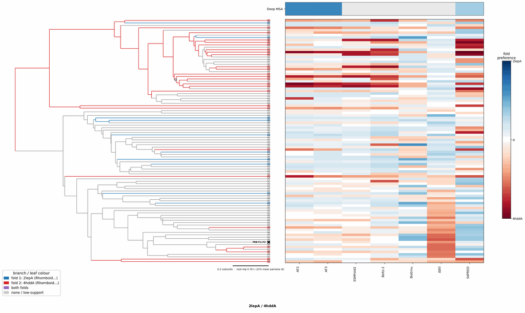

## Figure 2: Aligned overlay (both folds superposed)

The single fold-switching chain of each fold superposed by TM-align; waters hidden, any ligand shown as green sticks. Grey = structurally conserved core, colour = divergent (fold-switching) region.

2lepA (Rhomboid protease GlpG)4hddA (Rhomboid protease GlpG)Ligand MSE (bound to 4hddA)

TM-score: 0.396 · Trigger class: mutation

Aligned overlay

Loading...

## Figure 3: The two folds, side by side

Each fold is coloured by per-residue Cα deviation between the two superposed structures: grey ≈ conserved core, full colour = structurally divergent (fold-switching) region.

2lepA (Rhomboid protease GlpG)

4hddA (Rhomboid protease GlpG)

0 Å5≥10 Å

2lepA (Rhomboid protease GlpG)

Loading...

4hddA (Rhomboid protease GlpG)

Loading...

## Figure 4: Best-cluster predicted contact maps over the two true folds.

Predicted contact maps (MSA-Transformer) for the clusters best matching each fold, over the true contacts of fold 1 (upper triangle) and fold 2 (lower). Divergent contacts between clusters are the contact-level signature of fold-switching.

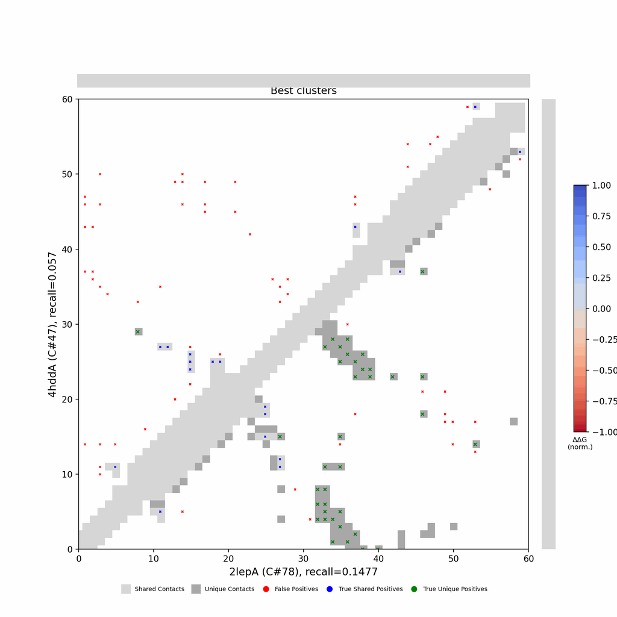

## Figure 5: Per-residue ΔΔG fold-preference contribution

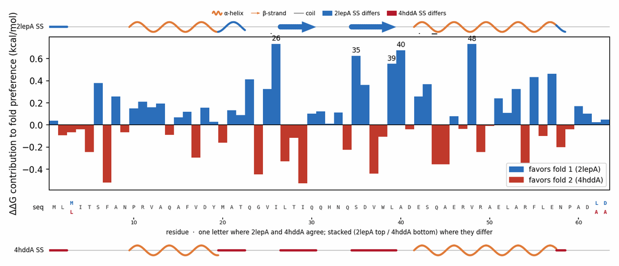

**More figures**

## Figure 6: Deep-MSA contact map panel / Best clusters contact map panel

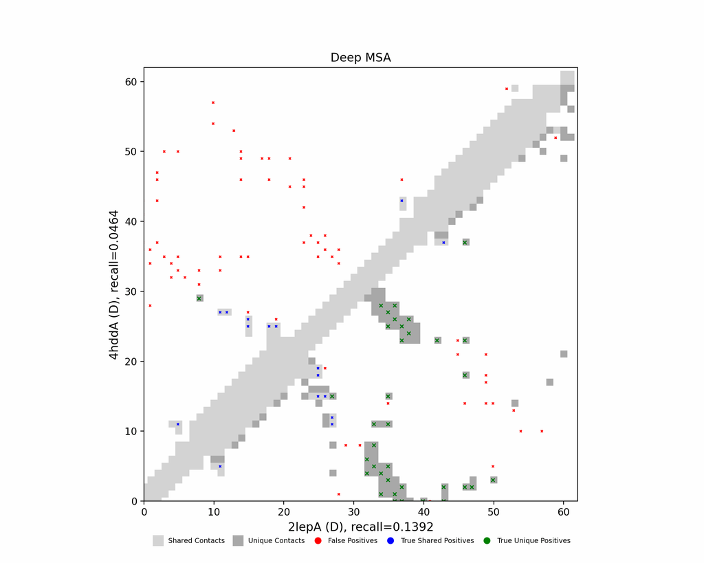

Deep-MSA contact map panel

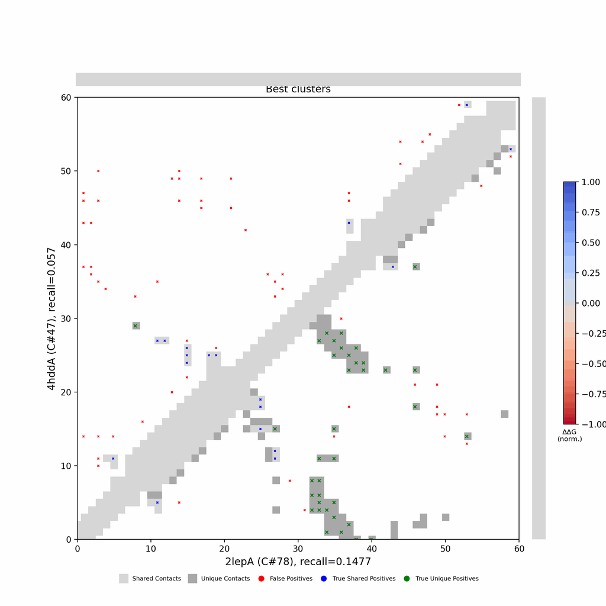

Best clusters contact map panel

## Figure 7: All clusters contact-map mosaic (small multiples).

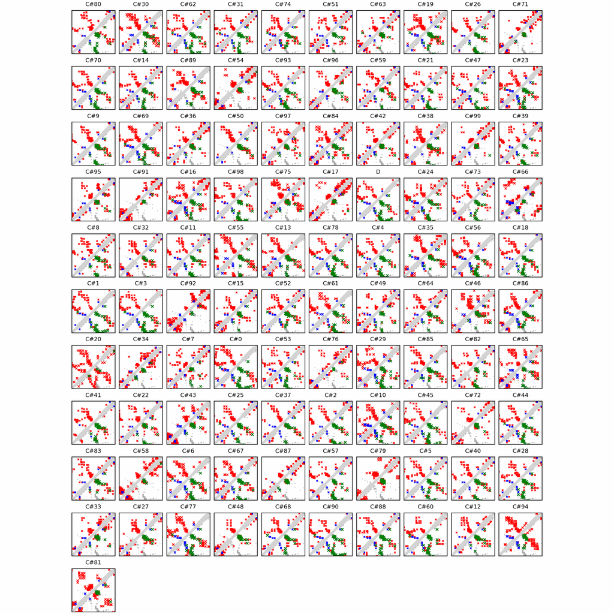

## Figure 8: Phylo null: tree with shuffled cluster fold labels.

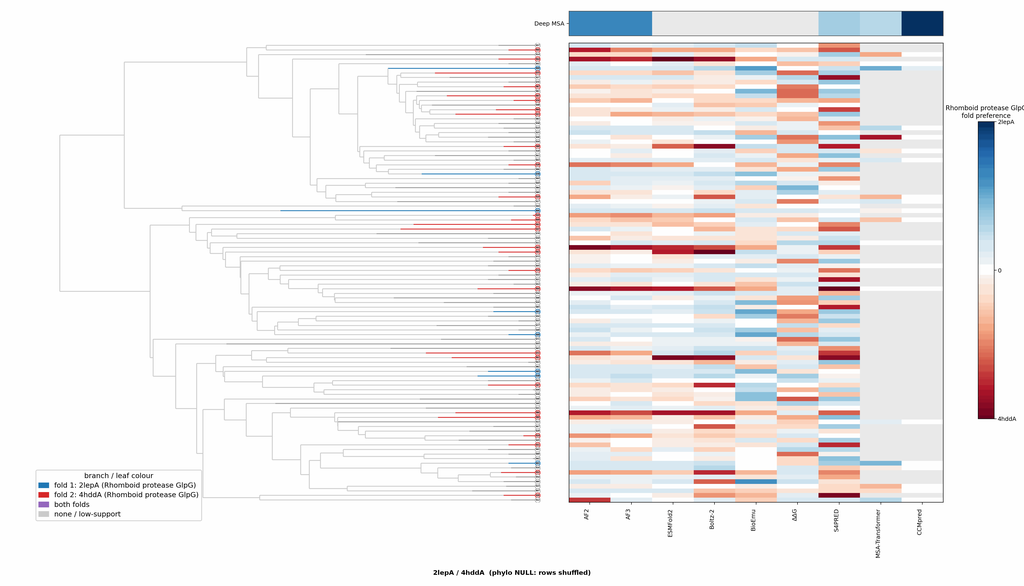

## Cluster metrics table

Per-cluster metrics underlying the figures above.

| cluster | n | neff | AF2_TM1 | AF2_TM2 | AF3_TM1 | AF3_TM2 | RE-MSAT-COM | RE-MSAT1 | RE-MSAT2 | ESM_SEQIDS | ESM_TM1 | ESM_TM2 | ΔΔG_Bias | ΔΔG_Bias_std | ΔΔG_frac_F1 | Boltz2_pref | S4PRED_pref | CCMpred_pref | BioEmu_pref |
| --- | --- | --- | --- | --- | --- | --- | --- | --- | --- | --- | --- | --- | --- | --- | --- | --- | --- | --- | --- |
| Deep | - | - | 0.76 | 0.52 | 0.76 | 0.51 | - | 0.54 | 0.0 | - | - | - | - | - | - | - | 0.08 | 0.11 | - |
| 000 | 501.0 | 229.0 | 0.76 | 0.4 | 0.77 | 0.42 | 0.0 | 0.44 | 0.0 | 005; 004; 005; 004; 009; 009; 008; 008; 006; 006 | 0.69 ± 0.03 | 0.43 ± 0.03 | 4.69 | 1.99 | 1.0 | 0.38 | 0.12 | 0.01 | 0.27 |
| 001 | 270.0 | 130.0 | 0.78 | 0.43 | 0.77 | 0.43 | 0.0 | 0.46 | 0.0 | 001; 001; 002; 004; 004; 002; 005; 005; 006; 006 | 0.69 ± 0.06 | 0.45 ± 0.04 | 3.08 | 1.62 | 1.0 | 0.36 | 0.15 | 0.0 | 0.12 |
| 002 | 208.0 | 55.0 | 0.75 | 0.42 | 0.74 | 0.46 | 0.0 | 0.24 | 0.0 | 001; 001; 004; 004; 003; 002; 003; 002; 006; 006 | 0.75 ± 0.02 | 0.43 ± 0.01 | 2.08 | 2.17 | 0.7 | 0.22 | 0.02 | 0.0 | 0.11 |
| 003 | 181.0 | 108.0 | 0.76 | 0.42 | 0.75 | 0.42 | 0.0 | 0.53 | 0.0 | 003; 003; 001; 002; 002; 001; 005; 005; 008; 006 | 0.74 ± 0.03 | 0.43 ± 0.03 | 3.66 | 2.25 | 0.9 | 0.32 | 0.08 | 0.0 | 0.16 |
| 004 | 103.0 | 64.0 | 0.32 | 0.37 | 0.32 | 0.35 | 0.0 | 0.44 | 0.0 | 001; 001; 002; 002; 003; 003; 004; 004; 006; 006 | 0.71 ± 0.04 | 0.43 ± 0.02 | 5.46 | 1.38 | 1.0 | 0.03 | -0.17 | 0.0 | 0.01 |
| 005 | 102.0 | 45.0 | 0.76 | 0.42 | 0.73 | 0.42 | 0.0 | 0.34 | 0.0 | 001; 001; 010; 010; 005; 005; 008; 002; 002; 008 | 0.73 ± 0.01 | 0.46 ± 0.03 | 5.45 | 2.27 | 1.0 | 0.34 | 0.06 | 0.0 | 0.18 |
| 006 | 89.0 | 44.0 | 0.76 | 0.42 | 0.77 | 0.41 | 0.0 | 0.32 | 0.0 | 001; 003; 001; 003; 002; 002; 007; 007; 006; 006 | 0.73 ± 0.02 | 0.44 ± 0.03 | 6.14 | 2.56 | 1.0 | 0.35 | 0.09 | 0.0 | 0.14 |
| 007 | 85.0 | 18.0 | 0.77 | 0.41 | 0.77 | 0.43 | 0.0 | 0.02 | 0.0 | 006; 006; 005; 005; 001; 001; 002; 002; 003; 003 | 0.72 ± 0.02 | 0.45 ± 0.03 | 3.63 | 1.96 | 1.0 | 0.17 | 0.02 | 0.0 | 0.04 |
| 008 | 82.0 | 16.0 | 0.74 | 0.44 | 0.7 | 0.45 | 0.0 | 0.09 | 0.0 | 002; 002; 003; 003; 005; 005; 004; 004; 006; 006 | 0.71 ± 0.03 | 0.42 ± 0.03 | 0.0 | 1.49 | 0.6 | 0.3 | 0.17 | 0.0 | 0.2 |
| 009 | 81.0 | 27.0 | 0.71 | 0.5 | 0.68 | 0.49 | 0.0 | 0.25 | 0.0 | 002; 002; 009; 009; 010; 001; 008; 005; 001; 008 | 0.69 ± 0.03 | 0.45 ± 0.03 | 2.21 | 2.15 | 0.8 | 0.29 | 0.11 | 0.0 | 0.16 |
| 010 | 80.0 | 34.0 | 0.77 | 0.41 | 0.75 | 0.41 | 0.0 | 0.22 | 0.0 | 001; 001; 002; 006; 006; 002; 009; 009; 010; 010 | 0.73 ± 0.03 | 0.44 ± 0.04 | 4.97 | 2.57 | 0.9 | 0.28 | -0.0 | 0.0 | 0.1 |
| 011 | 75.0 | 27.0 | 0.68 | 0.38 | 0.75 | 0.41 | 0.0 | 0.13 | 0.0 | 003; 003; 002; 002; 001; 001; 005; 005; 006; 006 | 0.70 ± 0.03 | 0.42 ± 0.03 | 7.0 | 1.08 | 1.0 | 0.34 | 0.14 | 0.0 | 0.06 |
| 012 | 72.0 | 26.0 | 0.31 | 0.29 | 0.69 | 0.37 | 0.0 | 0.11 | 0.0 | 001; 001; 006; 006; 002; 002; 003; 003; 007; 007 | 0.72 ± 0.03 | 0.46 ± 0.03 | 5.87 | 1.25 | 1.0 | 0.31 | 0.11 | 0.0 | 0.04 |
| 013 | 71.0 | 17.0 | 0.7 | 0.43 | 0.7 | 0.44 | 0.0 | 0.28 | 0.0 | 001; 001; 003; 008; 003; 008; 002; 005; 002; 005 | 0.72 ± 0.03 | 0.43 ± 0.03 | 2.62 | 1.84 | 1.0 | 0.27 | 0.08 | 0.0 | 0.13 |
| 014 | 69.0 | 23.0 | 0.63 | 0.4 | 0.61 | 0.4 | 0.0 | 0.34 | 0.0 | 001; 001; 002; 003; 003; 002; 007; 007; 006; 004 | 0.73 ± 0.02 | 0.44 ± 0.01 | 4.3 | 2.31 | 0.9 | 0.24 | 0.15 | 0.0 | 0.1 |
| 015 | 69.0 | 26.0 | 0.69 | 0.42 | 0.68 | 0.42 | 0.0 | 0.13 | 0.0 | 004; 004; 005; 005; 001; 007; 001; 007; 008; 008 | 0.70 ± 0.03 | 0.47 ± 0.03 | 4.49 | 2.06 | 1.0 | 0.28 | 0.02 | 0.0 | 0.09 |
| 016 | 69.0 | 22.0 | 0.77 | 0.42 | 0.76 | 0.42 | 0.0 | 0.25 | 0.0 | 003; 003; 002; 002; 006; 009; 007; 006; 007; 009 | 0.73 ± 0.01 | 0.44 ± 0.03 | 5.8 | 2.83 | 1.0 | 0.38 | 0.01 | 0.0 | 0.11 |
| 017 | 67.0 | 6.0 | 0.75 | 0.44 | 0.73 | 0.45 | 0.0 | 0.04 | 0.0 | 001; 001; 002; 002; 005; 005; 007; 007; 009; 009 | 0.74 ± 0.02 | 0.42 ± 0.03 | 0.18 | 1.56 | 0.5 | 0.29 | 0.09 | 0.0 | 0.17 |
| 018 | 64.0 | 31.0 | 0.7 | 0.41 | 0.72 | 0.4 | 0.0 | 0.3 | 0.0 | 010; 010; 001; 001; 005; 006; 006; 005; 003; 003 | 0.74 ± 0.02 | 0.45 ± 0.02 | 6.35 | 1.96 | 1.0 | 0.31 | 0.11 | 0.0 | 0.05 |
| 019 | 63.0 | 30.0 | 0.5 | 0.36 | 0.69 | 0.42 | 0.0 | 0.3 | 0.0 | 003; 003; 004; 004; 006; 006; 005; 005; 001; 001 | 0.72 ± 0.02 | 0.44 ± 0.01 | 4.48 | 2.42 | 1.0 | 0.04 | 0.04 | 0.0 | 0.14 |
| 020 | 62.0 | 34.0 | 0.6 | 0.46 | 0.61 | 0.5 | 0.06 | 0.05 | 0.09 | - | - | - | 4.1 | 1.52 | 1.0 | 0.12 | 0.07 | - | 0.09 |
| 021 | 62.0 | 21.0 | 0.74 | 0.41 | 0.76 | 0.4 | 0.0 | 0.25 | 0.0 | - | - | - | 5.29 | 2.8 | 1.0 | 0.35 | -0.13 | - | 0.08 |
| 022 | 62.0 | 13.0 | 0.69 | 0.41 | 0.74 | 0.45 | 0.0 | 0.17 | 0.0 | - | - | - | 0.52 | 1.96 | 0.5 | 0.29 | 0.16 | - | 0.09 |
| 023 | 61.0 | 20.0 | 0.58 | 0.34 | 0.44 | 0.3 | 0.0 | 0.3 | 0.0 | - | - | - | 2.34 | 1.5 | 1.0 | 0.17 | 0.16 | - | 0.05 |
| 024 | 60.0 | 20.0 | 0.47 | 0.35 | 0.47 | 0.33 | 0.0 | 0.27 | 0.0 | - | - | - | 6.29 | 1.93 | 1.0 | 0.15 | 0.07 | - | 0.06 |
| 025 | 60.0 | 22.0 | 0.78 | 0.4 | 0.76 | 0.42 | 0.0 | 0.11 | 0.0 | - | - | - | 5.98 | 1.7 | 1.0 | 0.37 | 0.07 | - | 0.02 |
| 026 | 60.0 | 13.0 | 0.75 | 0.41 | 0.73 | 0.44 | 0.0 | 0.15 | 0.0 | - | - | - | 0.7 | 2.35 | 0.6 | 0.35 | 0.01 | - | 0.24 |
| 027 | 59.0 | 22.0 | 0.77 | 0.4 | 0.76 | 0.4 | 0.0 | 0.13 | 0.0 | - | - | - | 6.85 | 1.15 | 1.0 | 0.26 | -0.14 | - | 0.13 |
| 028 | 59.0 | 33.0 | 0.48 | 0.39 | 0.49 | 0.38 | 0.0 | 0.33 | 0.0 | - | - | - | 5.2 | 2.6 | 1.0 | 0.22 | -0.04 | - | 0.02 |

[output cut: 71 more lines]